# assignment

## Descriptive stats

```python
# Function to calculate descriptive stats
def descriptive_stats(df):
    import numpy as np
    import pandas as pd
    new_df = df.describe(include='all')
    new_df=new_df.T
    new_df['Missing'] = df.isnull().sum()
    new_df = new_df.replace({np.nan: 'None'})
    return new_df
```

```python
descriptive_stats(df)
```

|  | count | unique | top | freq | mean | std | min | 25% | 50% | 75% | max | Missing |
| --- | --- | --- | --- | --- | --- | --- | --- | --- | --- | --- | --- | --- |
| Account length | 3333.0 | None | None | None | 101.064806 | 39.822106 | 1.0 | 74.0 | 101.0 | 127.0 | 243.0 | 0 |
| International plan | 3333.0 | 2 | No | 3010 | None | None | None | None | None | None | None | 0 |
| Voice mail plan | 3333.0 | 2 | No | 2411 | None | None | None | None | None | None | None | 0 |
| Number vmail messages | 3333.0 | None | None | None | 8.09901 | 13.688365 | 0.0 | 0.0 | 0.0 | 20.0 | 51.0 | 0 |
| Total day minutes | 3333.0 | None | None | None | 179.775098 | 54.467389 | 0.0 | 143.7 | 179.4 | 216.4 | 350.8 | 0 |
| Total day calls | 3333.0 | None | None | None | 100.435644 | 20.069084 | 0.0 | 87.0 | 101.0 | 114.0 | 165.0 | 0 |
| Total eve minutes | 3333.0 | None | None | None | 200.980348 | 50.713844 | 0.0 | 166.6 | 201.4 | 235.3 | 363.7 | 0 |
| Total eve calls | 3333.0 | None | None | None | 100.114311 | 19.922625 | 0.0 | 87.0 | 100.0 | 114.0 | 170.0 | 0 |
| Total night minutes | 3333.0 | None | None | None | 200.872037 | 50.573847 | 23.2 | 167.0 | 201.2 | 235.3 | 395.0 | 0 |
| Total night calls | 3333.0 | None | None | None | 100.107711 | 19.568609 | 33.0 | 87.0 | 100.0 | 113.0 | 175.0 | 0 |
| Total intl minutes | 3333.0 | None | None | None | 10.237294 | 2.79184 | 0.0 | 8.5 | 10.3 | 12.1 | 20.0 | 0 |
| Total intl calls | 3333.0 | None | None | None | 4.479448 | 2.461214 | 0.0 | 3.0 | 4.0 | 6.0 | 20.0 | 0 |
| Customer service calls | 3333.0 | None | None | None | 1.562856 | 1.315491 | 0.0 | 1.0 | 1.0 | 2.0 | 9.0 | 0 |
| Churn | 3333.0 | 2 | False | 2850 | None | None | None | None | None | None | None | 0 |

```python
#defining the studied or used independent features (columns) as well the target
target_col = ['Churn']
cols = [i for i in df.columns if i not in target_col]
```

```python
# Outlier Handling

from scipy import stats
def drop_numerical_outliers(df, z_thresh=3):
    print("dataframe shape {}  before Outlier handling.".format(df.shape))
    # Constrains will contain `True` or `False` depending on if it is a value below the threshold.
    constrains = df.select_dtypes(include=[np.number]).apply(lambda x: np.abs(stats.zscore(x)) < z_thresh).all(axis=1)
    # Drop (inplace) values set to be rejected
    df.drop(df.index[~constrains], inplace=True)
    print("dataframe shape {}  after Outlier handling.".format(df.shape))
    return df
df = drop_numerical_outliers(df)
```

```
dataframe shape (3333, 14)  before Outlier handling.
dataframe shape (3169, 14)  after Outlier handling.
```

## Handing imbalancy

##### Discussion:

```python
# unique values in target variable
df['Churn'].value_counts()
```

```
False    2727
True      442
Name: Churn, dtype: int64
```

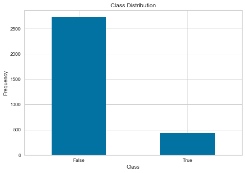

```python
#target variable visualization
count_classes = pd.value_counts(df['Churn'], sort = True)
count_classes.plot(kind = 'bar', rot=0)
plt.title("Class Distribution")
plt.xlabel("Class")
plt.ylabel("Frequency")
```

```python
# seggregating independent and dependent features
X = df.drop(target_col, axis = 1)
y = df[target_col]
```

```python
#Label encoding Binary columns
from sklearn.preprocessing import LabelEncoder
le = LabelEncoder()
# Categorical columns
bin_cols = X.nunique()[X.nunique() == 2].keys().tolist()
print('Categorical columns with 2 values are : ',bin_cols)
for i in bin_cols:
    X[i] = le.fit_transform(X[i])


# minimally prepare dataset
X = X.astype('float32')
y = LabelEncoder().fit_transform(y)
```

```
Categorical columns with 2 values are :  ['International plan', 'Voice mail plan']
```

```python
print("X set has {} samples before Oversampling.".format(X.shape[0]))
print("y set has {} samples before Oversampling.".format(y.shape[0]))
```

```
X set has 3169 samples before Oversampling.
y set has 3169 samples before Oversampling.
```

```python
#oversampling minority class using smote
from imblearn.over_sampling import SMOTE
smote = SMOTE(random_state = 42)
x_smote, y_smote = smote.fit_resample(X,y)
X = pd.DataFrame(data = x_smote, columns=cols)
y = pd.DataFrame(data = y_smote, columns=target_col)
print("X set has {} samples after Oversampling.".format(X.shape[0]))
print("y set has {} samples after Oversampling.".format(y.shape[0]))
```

```
X set has 5454 samples after Oversampling.
y set has 5454 samples after Oversampling.
```

```python
# Initialize a scaler, then apply it to the features
from sklearn.preprocessing import MinMaxScaler
scaler = MinMaxScaler() # default=(0, 1)
features_minmax_transformed = scaler.fit_transform(X)
X = pd.DataFrame(data=features_minmax_transformed,columns=X.columns)
```

##### Discussion: Since the data is numerical, it needs to be normalized.

- Certain features might be considerable higher in quantity than the other features.
- The algorithm would thus tend to get biased towards such features.
- Two approaches to deal with it:
  1. Standard Scaler: Scales the data to a unit variance by removing the column mean from each value. Outliers have an influence while calculating the mean and SD. Good to use if the data distribution is known to be normal. In our case, we have no idea about the data distribution. Thus this might not be an efficient way.
  2. MinMax Scalar: The entire data is transformed proportionally within 0 and 1 range. The original shape of the distibution remains the same.
- Using MinMax Scalar for now.

```python
#splitting the dataset to train and test datasets
from sklearn.model_selection import train_test_split
#creating target class for stratify
target_class = y.values
X_train, X_test, y_train, y_test = train_test_split(X, y, test_size = .25, random_state = 42,stratify=target_class)
print("Training set has {} samples.".format(X_train.shape[0]))
print("Test set has {} samples.".format(X_test.shape[0]))
```

```
Training set has 4090 samples.
Test set has 1364 samples.
```

## Model Building

```python
def train_prediction(algorithm, X_train, X_test, y_train, y_test, cf, threshold_plot=True):
    algorithm.fit(X_train, y_train)
    predictions = algorithm.predict(X_test)
    probabilities = algorithm.predict_proba(X_test)

    print('Algorithm:', type(algorithm).__name__)
    print("\nClassification report:\n", classification_report(y_test, predictions))
    print("Accuracy Score:", accuracy_score(y_test, predictions))

    #confusion matrix
    conf_matrix = confusion_matrix(y_test, predictions)
    #roc_auc_score
    model_roc_auc = roc_auc_score(y_test, predictions)
    print("Area under curve:", model_roc_auc,"\n")

    fpr, tpr, thresholds = roc_curve(y_test, probabilities[:,1])

    #plot confusion matrix
    trace1 = go.Heatmap(z = conf_matrix,
                        x = ["Not churn", "Churn"],
                        y = ["Not churn", "Churn"],
                        showscale = False, colorscale = "Picnic",
                        name = "Confusion matrix")

    #plot roc curve
    trace2 = go.Scatter(x = fpr, y = tpr,
                        name = "Roc: " + str(model_roc_auc),
                        line = dict(color = ('rgb(22, 96, 167)'), width = 2))
    trace3 = go.Scatter(x = [0,1], y = [0,1],
                        line = dict(color = ('rgb(205, 12, 24)'), width = 2,
                        dash = 'dot'))

    if cf in ['coefficients', 'features']:
        if cf == 'coefficients':
            coefficients = pd.DataFrame(algorithm.coef_.ravel())
        elif cf == 'features':
            coefficients = pd.DataFrame(algorithm.feature_importances_)

        column_df = pd.DataFrame(X_train.columns.tolist())
        coef_summary = (pd.merge(coefficients, column_df, left_index=True,
                               right_index=True, how="left"))
        coef_summary.columns = ["coefficients", "features"]
        coef_summary = coef_summary.sort_values(by = "coefficients", ascending=False)

        #plot coeffs
        trace4 = go.Bar(x = coef_summary["features"], y = coef_summary["coefficients"],
                        name = "coefficients",
                        marker = dict(color = coef_summary["coefficients"],
                                      colorscale = "Picnic",
                                      line = dict(width = .6, color = "black")
                                     )
                       )
        #subplots
        fig = make_subplots(rows=2, cols=2, specs=[[{}, {}], [{'colspan': 2}, None]],
                                subplot_titles=('Confusion matrix',
                                                'Receiver operating characteristic',
                                                'Feature importances')
                           )
        fig.append_trace(trace1,1,1)
        fig.append_trace(trace2,1,2)
        fig.append_trace(trace3,1,2)
        fig.append_trace(trace4,2,1)
        fig['layout'].update(showlegend=False, title="Model performance",
                             autosize=False, height = 900, width = 800,
                             plot_bgcolor = 'rgba(240,240,240, 0.95)',
                             paper_bgcolor = 'rgba(240,240,240, 0.95)',
                             margin = dict(b = 195))
        fig["layout"]["xaxis2"].update(dict(title = "false positive rate"))
        fig["layout"]["yaxis2"].update(dict(title = "true positive rate"))
        fig["layout"]["xaxis3"].update(dict(showgrid = True, tickfont = dict(size = 10), tickangle = 90))

    elif cf == 'None':
        #subplots
        fig = make_subplots(rows=1, cols=2,
                            subplot_titles=('Confusion matrix',
                                            'Receiver operating characteristic')
                           )
        fig.append_trace(trace1,1,1)
        fig.append_trace(trace2,1,2)
        fig.append_trace(trace3,1,2)
        fig['layout'].update(showlegend=False, title="Model performance",
                         autosize=False, height = 500, width = 800,
                         plot_bgcolor = 'rgba(240,240,240,0.95)',
                         paper_bgcolor = 'rgba(240,240,240,0.95)',
                         margin = dict(b = 195))
        fig["layout"]["xaxis2"].update(dict(title = "false positive rate"))
        fig["layout"]["yaxis2"].update(dict(title = "true positive rate"))

    py.iplot(fig)

    if threshold_plot == True:
        visualizer = DiscriminationThreshold(algorithm)
        visualizer.fit(X_train, y_train)
        visualizer.poof()
```

```python
#putting all the model names, model classes and the used columns in a dictionary
models = dict()
```

## Using Logistic Regression

```
Algorithm: LogisticRegression

Classification report:
               precision    recall  f1-score   support

           0       0.82      0.78      0.80       682
           1       0.79      0.82      0.81       682

    accuracy                           0.80      1364
   macro avg       0.80      0.80      0.80      1364
weighted avg       0.80      0.80      0.80      1364

Accuracy Score: 0.8005865102639296
Area under curve: 0.8005865102639296
```

[interactive chart not shown]

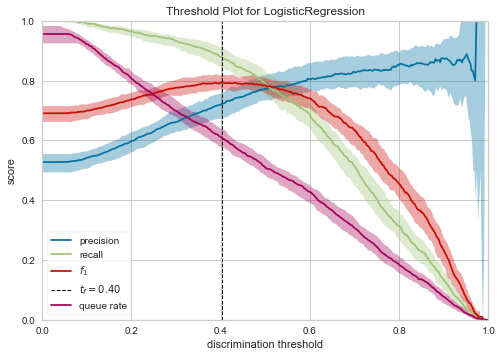

```python
from sklearn.linear_model import LogisticRegression

#Logistic Regression
logit = LogisticRegression(C=1.0, class_weight=None, dual=False, fit_intercept=True,
                           intercept_scaling=1, max_iter=100, multi_class='ovr', n_jobs=1,
                           penalty='l2', random_state=None, solver='liblinear', tol=0.0001,
                           verbose=0, warm_start=False)
#Calling model functionality
train_prediction(logit, X_train, X_test, y_train, y_test, "coefficients", threshold_plot=True)
# adding to model dictionary
models['LogisticRegression'] = [logit, cols]
```

## Random Forest Classifier

```
Algorithm: RandomForestClassifier

Classification report:
               precision    recall  f1-score   support

           0       0.93      0.95      0.94       682
           1       0.95      0.93      0.94       682

    accuracy                           0.94      1364
   macro avg       0.94      0.94      0.94      1364
weighted avg       0.94      0.94      0.94      1364

Accuracy Score: 0.9398826979472141
Area under curve: 0.9398826979472141
```

[interactive chart not shown]

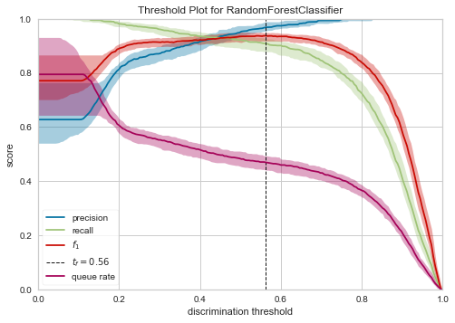

```python
from sklearn.ensemble import RandomForestClassifier
rfc = RandomForestClassifier(n_estimators = 100, random_state = 123,
                             max_depth = 9, criterion = "gini")
#Calling model functionality
train_prediction(rfc, X_train, X_test, y_train, y_test, 'features', threshold_plot=True)
# adding to model dictionary
models['RandomForestClassifier'] = [rfc, cols]
```

## KNN Classifier

```
Algorithm: KNeighborsClassifier

Classification report:
               precision    recall  f1-score   support

           0       0.97      0.82      0.89       682
           1       0.84      0.97      0.90       682

    accuracy                           0.90      1364
   macro avg       0.90      0.90      0.89      1364
weighted avg       0.90      0.90      0.89      1364

Accuracy Score: 0.8951612903225806
Area under curve: 0.8951612903225806
```

[interactive chart not shown]

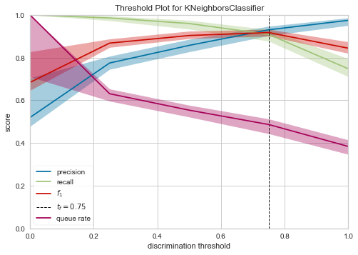

```python
from sklearn.neighbors import KNeighborsClassifier

knn = KNeighborsClassifier(algorithm='auto', leaf_size=30, metric='minkowski',
                           metric_params=None, n_jobs=1, n_neighbors=5, p=2,
                           weights='uniform')
#Calling model functionality
train_prediction(knn, X_train, X_test, y_train, y_test, 'None', threshold_plot=True)
# adding to model dictionary
models['KneighborsClassifier'] = [knn, cols]
```

## Support Vector Machine (Linear)

```
Algorithm: SVC

Classification report:
               precision    recall  f1-score   support

           0       0.82      0.77      0.79       682
           1       0.78      0.83      0.81       682

    accuracy                           0.80      1364
   macro avg       0.80      0.80      0.80      1364
weighted avg       0.80      0.80      0.80      1364

Accuracy Score: 0.8005865102639296
Area under curve: 0.8005865102639296
```

[interactive chart not shown]

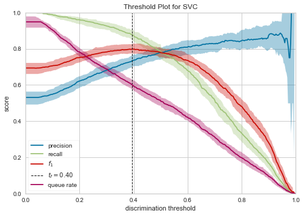

```python
from sklearn.svm import SVC

#Support vector classifier using linear hyper plane
svc_lin  = SVC(C=1.0, kernel='linear', probability=True, random_state=124)
#Calling model functionality
train_prediction(svc_lin, X_train, X_test, y_train, y_test, 'coefficients', threshold_plot=True)
# adding to model dictionary
models['SVC'] = [svc_lin, cols]
```

## LightGBM Classifier

```
Algorithm: LGBMClassifier

Classification report:
               precision    recall  f1-score   support

           0       0.97      0.99      0.98       682
           1       0.99      0.97      0.98       682

    accuracy                           0.98      1364
   macro avg       0.98      0.98      0.98      1364
weighted avg       0.98      0.98      0.98      1364

Accuracy Score: 0.9787390029325513
Area under curve: 0.9787390029325513
```

[interactive chart not shown]

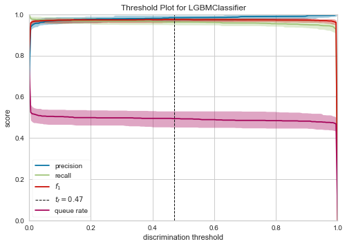

```python
from lightgbm import LGBMClassifier

lgbmc = LGBMClassifier(boosting_type='gbdt', class_weight=None, colsample_bytree=1.0,
                        learning_rate=0.5, max_depth=7, min_child_samples=20,
                        min_child_weight=0.001, min_split_gain=0.0, n_estimators=100,
                        n_jobs=-1, num_leaves=500, objective='binary', random_state=None,
                        reg_alpha=0.0, reg_lambda=0.0, silent=True, subsample=1.0,
                        subsample_for_bin=200000, subsample_freq=0)
#Calling model functionality
train_prediction(lgbmc, X_train, X_test, y_train, y_test, "features", threshold_plot=True)
# adding to model dictionary
models['LGBMClassifier'] = [lgbmc, cols]
```

```python
models
```

```
{'LogisticRegression': [LogisticRegression(multi_class='ovr', n_jobs=1, solver='liblinear'),
  ['Account length',
   'International plan',
   'Voice mail plan',
   'Number vmail messages',
   'Total day minutes',
   'Total day calls',
   'Total eve minutes',
   'Total eve calls',
   'Total night minutes',
   'Total night calls',
   'Total intl minutes',
   'Total intl calls',
   'Customer service calls']],
 'RandomForestClassifier': [RandomForestClassifier(max_depth=9, random_state=123),
  ['Account length',
   'International plan',
   'Voice mail plan',
   'Number vmail messages',
   'Total day minutes',
   'Total day calls',
   'Total eve minutes',
   'Total eve calls',
   'Total night minutes',
   'Total night calls',
   'Total intl minutes',
   'Total intl calls',
   'Customer service calls']],
 'KneighborsClassifier': [KNeighborsClassifier(n_jobs=1),
  ['Account length',
   'International plan',
   'Voice mail plan',
   'Number vmail messages',
   'Total day minutes',
   'Total day calls',
   'Total eve minutes',
   'Total eve calls',
   'Total night minutes',
   'Total night calls',
   'Total intl minutes',
```

[output cut: 16 more lines]

```
 'LGBMClassifier': [LGBMClassifier(learning_rate=0.5, max_depth=7, num_leaves=500,
                 objective='binary', silent=True),
  ['Account length',
   'International plan',
   'Voice mail plan',
   'Number vmail messages',
   'Total day minutes',
   'Total day calls',
   'Total eve minutes',
   'Total eve calls',
   'Total night minutes',
   'Total night calls',
   'Total intl minutes',
   'Total intl calls',
   'Customer service calls']]}
```

## Model performance metrics

```python
#gives model report in dataframe
def model_report_generation(model, X_train, X_test, y_train, y_test, name):
    model = model.fit(X_train, y_train)
    predictions = model.predict(X_test)
    accuracy = accuracy_score(y_test, predictions)
    recallscore = recall_score(y_test, predictions)
    precision = precision_score(y_test, predictions)
    roc_auc = roc_auc_score(y_test, predictions)
    f1score = f1_score(y_test, predictions)
    kappa_metric = cohen_kappa_score(y_test, predictions)

    df = pd.DataFrame({"Model"           : [name],
                       "Accuracy"        : [accuracy],
                       "Recall"          : [recallscore],
                       "Precision"       : [precision],
                       "f1-score"        : [f1score],
                       "Roc_auc"         : [roc_auc],
                       "Kappa_metric"    : [kappa_metric],
                      })
    return df
```

```python
#outputs for all models over the training dataset
model_performances = pd.DataFrame()
for name in models:
    model_performances = model_performances.append(model_report_generation(models[name][0], X_train[models[name][1]],
                                                                                X_test[models[name][1]],
                                                                                y_train, y_test, name), ignore_index=True)
model_performances = model_performances.sort_values(by=['Accuracy'], ascending=False)
performance_table = ff.create_table(np.round(model_performances, 4))
py.iplot(performance_table)
```

[interactive chart not shown]

## Compare model metrics

```python
# Function to define output tracer for plotting
def output_tracer(df, metric, color):
    tracer = go.Bar(y = df["Model"],
                    x = df[metric],
                    orientation = "h", name = metric ,
                    marker = dict(line = dict(width =.7), color = color)
                   )
    return tracer
```

```python
# Function for model metrics plots
def model_metrics_plot(df, title):
    layout = go.Layout(dict(title = title,
                        plot_bgcolor = "rgb(243,243,243)",
                        paper_bgcolor = "rgb(243,243,243)",
                        xaxis = dict(gridcolor = 'rgb(255, 255, 255)',
                                     title = "metric",
                                     zerolinewidth=1,
                                     ticklen=5, gridwidth=2),
                        yaxis = dict(gridcolor = 'rgb(255, 255, 255)',
                                     zerolinewidth=1, ticklen=5, gridwidth=2),
                        margin = dict(l = 250),
                        height = 780
                       )
                  )
    trace1 = output_tracer(df, "Accuracy", "#6699FF")
    trace2 = output_tracer(df, 'Recall', "red")
    trace3 = output_tracer(df, 'Precision', "#33CC99")
    trace4 = output_tracer(df, 'f1-score', "lightgrey")
    trace5 = output_tracer(df, 'Roc_auc', "magenta")
    trace6 = output_tracer(df, 'Kappa_metric', "#FFCC99")

    data = [trace1, trace2, trace3, trace4, trace5, trace6]
    fig = go.Figure(data=data, layout=layout)
    return py.iplot(fig)
```

```python
# model metrics visualizations
model_metrics_plot(df=model_performances.sort_values(by=['Accuracy']), title="Model performances")
```

[interactive chart not shown]